# classification_modeling_bank_marketing

- Show All Code
- Hide All Code
- View Source

## Classification Modeling | Bank Marketing

##### February 18, 2026

#### DAT-5329 | Machine Learning & AI

#### By: **Renan Peres** | https://github.com/renan-peres/

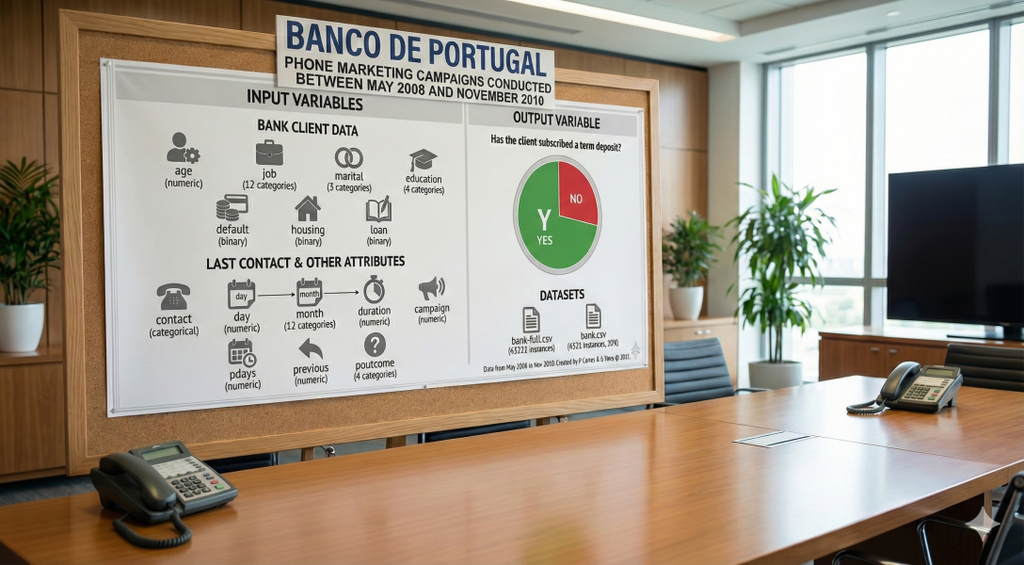

Bank Marketing

## **Executive Summary**

### Overview and Objective

Marketing relies on delivering the right product, to the right customer, at the right time. Achieving this requires a process that relies on more than just intuition, it requires data driven decision making. In this project we are using machine learning to build a predictive classification model based on a dataset from the UCI Machine Learning Repository. The dataset originates from a Portuguese banking institution and focuses on direct marketing campaigns conducted via phone calls between May 2008 and November 2010.

The primary business goal associated with this data is to develop a classification model to predict whether a client will subscribe to a specific financial product: a **bank term deposit (target variable y)**. It is noted that securing a subscription often required multiple contacts with the same client. Instead of contacting customers aimlessly, we identify those most likely to respond positively. By comparing classification models and improving performance through preprocessing, feature engineering and hyperparameter tuning, we develop a system that increases efficiency, reduces costs, and improves campaign effectiveness. This project shows how machine learning allows businesses to improve marketing efficiency by moving from broad segmentation to predictive, data driven targeting.

### Dataset Characteristics

- **Source:** Moro, S., Rita, P., & Cortez, P. (2014). Bank Marketing Dataset. [UCI Machine Learning Repository](https://archive.ics.uci.edu/dataset/222/bank+marketing).
- **Volume:** 45,211 instances (full dataset, `bank-full.csv`). A 10% subset (`bank.csv`, 4,521 instances) is available for computationally intensive testing.
- **Data quality:** No missing attribute values.

### Feature Summary

The dataset contains 16 input features and 1 binary target (`y` → `has_subscribed`). Inputs fall into three groups:

- **Client demographics:** age, job type, marital status, education level, credit default, average yearly balance, housing loan, and personal loan.
- **Current campaign contacts:** communication type (telephone/cellular), day of month, month, and call duration.
- **Campaign history:** total contacts this campaign, days since last contact from a prior campaign, number of prior contacts, and previous campaign outcome.

### Model Selection

We trained and compared five classifiers: Logistic Regression, Random Forest, XGBoost, Neural Network (MLP), and AdaBoost using **ROC-AUC** as the primary selection metric. ROC-AUC measures how well a model separates positive from negative cases across all probability thresholds, making it well-suited for imbalanced data.

> **XGBoost** achieved the highest test ROC-AUC of **0.795** with a train–test gap of only **0.013**, well below the 0.05 overfitting threshold.

## **Imports**

### Libraries

```python
# data manipulation
import numpy                   as np                                  # mathematical essentials
import pandas                  as pd                                  # data science essentials

# data visualization
import matplotlib.pyplot       as plt                                 # data visualization
import seaborn                 as sns                                 # enhanced visualization

# data preprocessing
from sklearn.preprocessing     import StandardScaler                  # data prep
from sklearn.model_selection   import train_test_split                # train-test split
from sklearn.model_selection   import RandomizedSearchCV              # hyperparameter tuning
from sklearn.model_selection   import GridSearchCV                    # hyperparameter tuning

# ML models
import xgboost                 as xgb                                 # eXtreme Gradient Boosting
from sklearn.base              import clone                           # clone estimator
from sklearn.linear_model      import LogisticRegression              # logistic regression
from sklearn.ensemble          import RandomForestClassifier          # random forest
from sklearn.ensemble          import AdaBoostClassifier              # AdaBoost
from sklearn.neural_network    import MLPClassifier                   # neural networks

# metrics
from sklearn.metrics           import confusion_matrix                # confusion matrix
from sklearn.metrics           import roc_auc_score                   # auc score
from sklearn.metrics           import accuracy_score                  # accuracy score
from sklearn.metrics           import precision_score, recall_score   # precision and recall
from sklearn.metrics           import f1_score                        # f1 score
from sklearn.metrics           import average_precision_score         # avg precision score

# setting pandas print options
pd.set_option('display.max_rows'    , 500)
pd.set_option('display.max_columns' , 500)
pd.set_option('display.width'       , 1000)

# suppressing warnings
import warnings
warnings.filterwarnings(action = 'ignore')
```

### UDFs (User-Defined Functions)

#### `plot_feature_importances()`

Plots a horizontal bar chart of non-zero feature importances from any tree-based model. Filtering out zero-importance features keeps the chart readable and highlights only the drivers that influence predictions.

```python
def plot_feature_importances(model, train, title=None, export=False, top_n=None):

    importances = model.feature_importances_
    cols        = np.array(train.columns)

    # keep only features with non-zero importance
    mask        = importances > 0
    importances = importances[mask]
    cols        = cols[mask]

    # sort ascending for horizontal bar layout
    order       = np.argsort(importances)
    importances = importances[order]
    cols        = cols[order]

    if top_n is not None:
        importances = importances[-top_n:]
        cols        = cols[-top_n:]

    fig, ax = plt.subplots(figsize=(10, 8))
    ax.barh(range(len(cols)), importances, align="center")
    ax.set_yticks(range(len(cols)))
    ax.set_yticklabels(cols)
    if title is not None:
        ax.set_title(title)
    ax.set_xlabel("Feature importance")

    if export:
        plt.savefig("./analysis_images/Tree_Visual.png", bbox_inches="tight")

    plt.show()
```

#### `evaluate_classification_model()`

Evaluates a fitted classifier by computing ROC-AUC (train and test), PR-AUC, accuracy, precision, recall, and F1 on the test set. It also reports the train–test ROC-AUC gap, which we use to diagnose overfitting. An optional confusion-matrix heatmap can be toggled on for the winning model.

```python
def evaluate_classification_model(model, x_train, x_test, y_train, y_test,
                                  model_name="Model", show_confusion_matrix=False):
    """
    PARAMETERS
    ----------
    model                  : fitted sklearn-compatible classifier
    x_train                : training features
    x_test                 : testing features
    y_train                : training target
    y_test                 : testing target
    model_name             : string label for display
    show_confusion_matrix  : bool, if True displays confusion matrix (default: False)

    RETURNS
    -------
    results : dict with all computed metrics
    """
    # predictions (binary)
    y_train_pred = model.predict(x_train)
    y_test_pred  = model.predict(x_test)


    # predicted probabilities for the positive class (needed for PR-AUC & ROC-AUC)
    y_test_proba  = model.predict_proba(x_test)[:, 1]
    y_train_proba = model.predict_proba(x_train)[:, 1]


    # core metrics — PR-AUC and ROC-AUC use PROBABILITIES, not binary predictions
    pr_auc        = average_precision_score(y_test, y_test_proba)
    acc_train     = accuracy_score(y_train, y_train_pred)
    acc_test      = accuracy_score(y_test,  y_test_pred)
    roc_auc_train = roc_auc_score(y_true=y_train, y_score=y_train_proba)
    roc_auc_test  = roc_auc_score(y_true=y_test,  y_score=y_test_proba)
    prec          = precision_score(y_test, y_test_pred)
    rec           = recall_score(y_test, y_test_pred)
    f1            = f1_score(y_test, y_test_pred)


    # print summary
    print(f"{'='*45}")
    print(f"  {model_name}")
    print(f"{'='*45}")
    print(f"  ROC-AUC Train  : {roc_auc_train:.3f}")
    print(f"  ROC-AUC Test   : {roc_auc_test:.3f}")
    print(f"  ROC-AUC Gap    : {abs(roc_auc_train - roc_auc_test):.3f}")
    print(f"  PR-AUC         : {pr_auc:.3f}")
    print(f"  Accuracy       : {acc_test:.3f}")
    print(f"  Precision      : {prec:.3f}")
    print(f"  Recall         : {rec:.3f}")
    print(f"  F1 Score       : {f1:.3f}")
    print(f"{'='*45}\n")


    # confusion matrix (only if requested)
    if show_confusion_matrix:
        cm = confusion_matrix(y_test, y_test_pred)
        plt.figure(figsize=(5, 4))
        sns.heatmap(cm, annot=True, fmt='d', cmap='Blues',
                    xticklabels=['No', 'Yes'],
                    yticklabels=['No', 'Yes'])
        plt.title(f'Confusion Matrix - {model_name}')
        plt.ylabel('Actual')
        plt.xlabel('Predicted')
        plt.tight_layout()
        plt.show()


    return {
        'model_name'    : model_name,
        'roc_auc_train' : round(roc_auc_train, 3),
        'roc_auc_test'  : round(roc_auc_test, 3),
        'roc_auc_gap'   : round(abs(roc_auc_train - roc_auc_test), 3),
        'PR-AUC'        : round(pr_auc, 3),
        'accuracy'      : round(acc_test, 3),
        'precision'     : round(prec, 3),
        'recall'        : round(rec, 3),
        'f1'            : round(f1, 3)
    }
```

### Dataset

```python
# local file
file = 'bank-full.csv'

# reading the file into Python
df      = pd.read_csv(filepath_or_buffer = file ,
                      header             = 0    ,
                      delimiter          = ';'    # semicolon delimited
                      )
```

## **Step 1: Exploratory Data Analysis (EDA)**

Before modeling, we examine the dataset’s structure, distributions, and class balance to inform preprocessing decisions.

### Dataset Shape

```python
print("Shape:", df.shape)
display(df.head(n = 5))
```

```
Shape: (45211, 17)
```

|  | age | job | marital | education | default | balance | housing | loan | contact | day | month | duration | campaign | pdays | previous | poutcome | y |
| --- | --- | --- | --- | --- | --- | --- | --- | --- | --- | --- | --- | --- | --- | --- | --- | --- | --- |
| 0 | 58 | management | married | tertiary | no | 2143 | yes | no | unknown | 5 | may | 261 | 1 | -1 | 0 | unknown | no |
| 1 | 44 | technician | single | secondary | no | 29 | yes | no | unknown | 5 | may | 151 | 1 | -1 | 0 | unknown | no |
| 2 | 33 | entrepreneur | married | secondary | no | 2 | yes | yes | unknown | 5 | may | 76 | 1 | -1 | 0 | unknown | no |
| 3 | 47 | blue-collar | married | unknown | no | 1506 | yes | no | unknown | 5 | may | 92 | 1 | -1 | 0 | unknown | no |
| 4 | 33 | unknown | single | unknown | no | 1 | no | no | unknown | 5 | may | 198 | 1 | -1 | 0 | unknown | no |

### Data Types

```python
print(f"""
Data Types (Count):
{df.dtypes.value_counts()}

Data Types:
{df.dtypes}
""")
```

```
Data Types (Count):
object    10
int64      7
Name: count, dtype: int64

Data Types:
age           int64
job          object
marital      object
education    object
default      object
balance       int64
housing      object
loan         object
contact      object
day           int64
month        object
duration      int64
campaign      int64
pdays         int64
previous      int64
poutcome     object
y            object
dtype: object
```

### Missing Values

```python
missing = df.isnull().sum().sort_values(ascending=False)
zeros   = (df == 0).sum().sort_values(ascending=False)

summary = pd.concat(
    [missing.rename("Missing Values"),
     zeros.rename("Zero Values")],
    axis=1
)

print(summary)
```

```
           Missing Values  Zero Values
age                     0            0
job                     0            0
marital                 0            0
education               0            0
default                 0            0
balance                 0         3514
housing                 0            0
loan                    0            0
contact                 0            0
day                     0            0
month                   0            0
duration                0            3
campaign                0            0
pdays                   0            0
previous                0        36954
poutcome                0            0
y                       0            0
```

### Descriptive Statistics

```python
round(df.describe().T, 2) \
  .sort_values(by = 'std', ascending = False) # sorted by standard deviation in descending order
```

|  | count | mean | std | min | 25% | 50% | 75% | max |
| --- | --- | --- | --- | --- | --- | --- | --- | --- |
| balance | 45211.0 | 1362.27 | 3044.77 | -8019.0 | 72.0 | 448.0 | 1428.0 | 102127.0 |
| duration | 45211.0 | 258.16 | 257.53 | 0.0 | 103.0 | 180.0 | 319.0 | 4918.0 |
| pdays | 45211.0 | 40.20 | 100.13 | -1.0 | -1.0 | -1.0 | -1.0 | 871.0 |
| age | 45211.0 | 40.94 | 10.62 | 18.0 | 33.0 | 39.0 | 48.0 | 95.0 |
| day | 45211.0 | 15.81 | 8.32 | 1.0 | 8.0 | 16.0 | 21.0 | 31.0 |
| campaign | 45211.0 | 2.76 | 3.10 | 1.0 | 1.0 | 2.0 | 3.0 | 63.0 |
| previous | 45211.0 | 0.58 | 2.30 | 0.0 | 0.0 | 0.0 | 0.0 | 275.0 |

```python
# skewness for numeric columns
print(df.skew(numeric_only=True).round(2).sort_values(ascending=False))
```

```
previous    41.85
balance      8.36
campaign     4.90
duration     3.14
pdays        2.62
age          0.68
day          0.09
dtype: float64
```

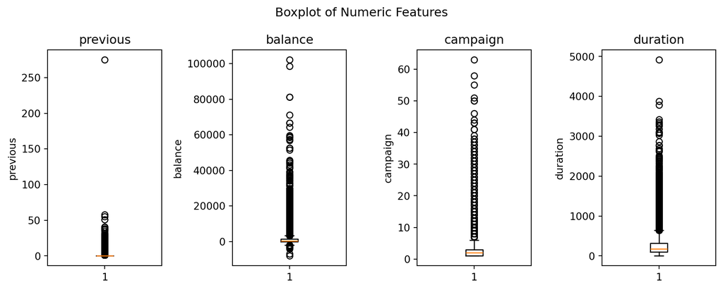

```python
# boxplot of key numeric features
num_cols  = ['previous', 'balance', 'campaign', 'duration']

fig, axes = plt.subplots(1, len(num_cols), figsize=(10, 4), sharey=False)

for ax, col in zip(axes, num_cols):
    ax.boxplot(df[col].dropna(), vert=True)
    ax.set_title(col)
    ax.set_ylabel(col)  # separate scale per subplot

fig.suptitle('Boxplot of Numeric Features')
plt.tight_layout()
plt.show()
```

### Target variable distribution

```
Target Variable Distribution:
-----------------------------
y
no     39922
yes     5289
Name: count, dtype: int64

Class Proportions:
------------------------------
y
no     0.883015
yes    0.116985
Name: proportion, dtype: float64
```

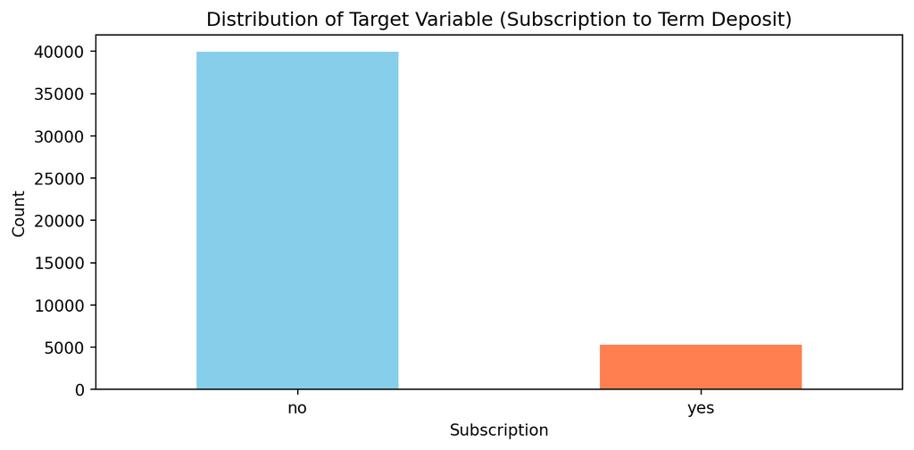

```python
# Check class distribution
print(f"""
Target Variable Distribution:
-----------------------------
{df['y'].value_counts()}

Class Proportions:
------------------------------
{df['y'].value_counts(normalize=True)}
""")

# Visualize class distribution
plt.figure(figsize=(8, 4))
df['y'].value_counts().plot(kind='bar', color=['skyblue', 'coral'])
plt.title('Distribution of Target Variable (Subscription to Term Deposit)')
plt.xlabel('Subscription')
plt.ylabel('Count')
plt.xticks(rotation=0)
plt.tight_layout()
plt.show()
```

> The target is heavily imbalanced — “no” cases far outnumber “yes.” This means raw accuracy would be misleading (a model predicting all “no” would score high). To address this, we both **downsample the majority class** in training and use **ROC-AUC** as the primary evaluation metric, which is robust to class imbalance.

## **Step 2: Data Preparation / Cleaning**

This step prepares the raw data for modeling by improving column readability and addressing outliers that could distort model training.

### Column Renaming

The original UCI column names are short abbreviations (e.g., `pdays`, `poutcome`). We rename them to descriptive labels (e.g., `contact_gap_days`, `previous_outcome`) so the code and feature-importance plots are easier to interpret.

```python
# Rename the columns for interpretability
df.rename(columns = {'job'       : 'job_type'           ,
                     'marital'   : 'marital_status'     ,
                     'education' : 'education_level'    ,
                     'default'   : 'has_default'        ,
                     'balance'   : 'avg_yearly_balance' ,
                     'housing'   : 'has_housing'        ,
                     'loan'      : 'has_loan'           ,
                     'contact'   : 'contact_type'       ,
                     'duration'  : 'contact_duration'   ,
                     'campaign'  : 'campaign_contacts'  ,
                     'pdays'     : 'contact_gap_days'   ,
                     'previous'  : 'previous_contacts'  ,
                     'poutcome'  : 'previous_outcome'   ,
                     'y'         : 'has_subscribed'
                     },
          inplace = True)

# Lowercase and remove whitespace
df.columns = df.columns.str.lower().str.strip()
```

### Outlier Imputation

We apply IQR-based outlier imputation to two numeric features: `avg_yearly_balance` and `campaign_contacts`, that showed heavy right-skew and extreme values in the EDA boxplots above. (`contact_duration` is excluded because it will be dropped as a leakage variable before modeling.)

- **Detection:** Values below Q1 − 1.5 × IQR or above Q3 + 1.5 × IQR are flagged as outliers.
- **Imputation:** Flagged values are replaced with the column **median**, which preserves central tendency without introducing artificial distributional assumptions.

This reduces the influence of extreme observations (e.g., very high balances or excessive campaign contacts) on model training, particularly for distance-based and linear models.

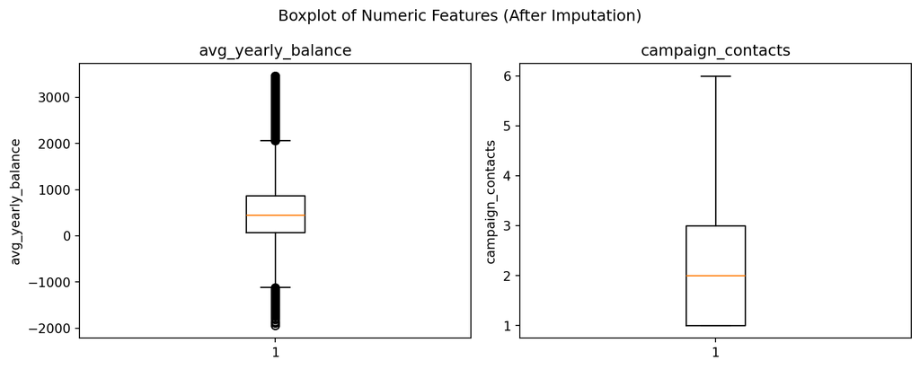

```python
# Redefining with new column names (contact_duration excluded — it is dropped later as a leakage variable)
num_cols = ['avg_yearly_balance', 'campaign_contacts']

# Loop through numeric columns
for col in num_cols:

    # Define quartiles and IQR
    Q1  = df[col].quantile(0.25)
    Q3  = df[col].quantile(0.75)
    IQR = Q3 - Q1

    # Define outlier bounds (1.5 * IQR) and calculate median
    lower  = Q1 - 1.5 * IQR
    upper  = Q3 + 1.5 * IQR
    median = df[col].median()

    # Replace outliers with median
    df.loc[df[col] < lower, col] = median
    df.loc[df[col] > upper, col] = median

# boxplot of key numeric features
fig, axes = plt.subplots(1, len(num_cols), figsize=(10, 4), sharey=False)

for ax, col in zip(axes, num_cols):
    ax.boxplot(df[col].dropna(), vert=True)
    ax.set_title(col)
    ax.set_ylabel(col)  # separate scale per subplot

fig.suptitle('Boxplot of Numeric Features (After Imputation)')
plt.tight_layout()
plt.show()
```

> The post-imputation boxplots confirm that extreme tails have been compressed. The distributions are not perfectly normal, but the most distorting outliers no longer skew the feature ranges.

## **Step 3: Feature Engineering**

We created **18 engineered features** across six categories to give models richer signals about customer behavior, financial health, and campaign dynamics. Each category and its rationale are summarized below.

### **Categorical Binning (3 features)**

| # | Feature | Description |
| --- | --- | --- |
| 1 | `AGE_GROUP` | Age binned into six life-stage groups (<25, 25–35, …, 65+) |
| 2 | `CAMPAIGN_INTENSITY_BIN` | Campaign contacts binned into four frequency levels |
| 3 | `PREVIOUS_SUCCESS` | Binary flag: previous campaign outcome was “success” |

> Binning continuous variables lets models detect non-linear threshold effects (e.g., retirees vs. mid-career) that raw numeric values may miss.

### **Customer Financial Profile (3 features)**

| # | Feature | Description |
| --- | --- | --- |
| 4 | `FINANCIAL_STABILITY_SCORE` | Composite 0–1 score from balance, default, and debt status |
| 5 | `BALANCE_PER_AGE` | Wealth accumulation rate (balance ÷ age) |
| 6 | `DEBT_FREE_STATUS` | Binary: no housing loan, personal loan, or credit default |

> Financially stable, debt-free customers with higher wealth-to-age ratios are more likely to have disposable income for term deposits.

### **Campaign Engagement (4 features)**

| # | Feature | Description |
| --- | --- | --- |
| 7 | `PRIOR_CONTACT_FLAG` | Binary: customer was contacted in a prior campaign |
| 8 | `CAMPAIGN_INTENSITY` | Ratio of current to previous campaign contacts |
| 9 | `ENGAGEMENT_QUALITY_SCORE` | Composite 0–1 score weighting prior success (3×) and prior contact (2×) |
| 10 | `CONTACT_RECENCY_SCORE` | Normalized 0–1 recency (recent contact = 1, never contacted = 0) |

> Customers with prior successful interactions and recent contact are warmer leads. The intensity ratio captures how aggressively the current campaign targets each customer relative to past efforts.

### **Demographic Profile (3 features)**

| # | Feature | Description |
| --- | --- | --- |
| 11 | `LIFE_STAGE_CATEGORY` | Four segments: young_single, middle_married, mature, other |
| 12 | `EDUCATION_JOB_ALIGNMENT` | Binary: tertiary education paired with management/admin job |
| 13 | `EMPLOYMENT_STABILITY_SCORE` | Ordinal 1–3 score by job stability |

> Life stage and employment stability influence financial product adoption. Aligned education-job profiles tend to signal higher income potential.

### **Temporal Patterns (2 features)**

| # | Feature | Description |
| --- | --- | --- |
| 14 | `PEAK_SEASON_FLAG` | Binary: contact made during May–August |
| 15 | `MONTH_PERIOD_CATEGORY` | Month timing: early (1–10), mid (11–20), late (21–31) |

> Conversion rates vary seasonally and within-month (e.g., post-salary-deposit timing).

### **Interaction Features (3 features)**

| # | Feature | Description |
| --- | --- | --- |
| 16 | `CAMPAIGN_SUCCESS_INTERACTION` | campaign_contacts × previous success flag |
| 17 | `AGE_BALANCE_INTERACTION` | age × balance (wealth-life-stage effect) |
| 18 | `CAMPAIGN_CONTACT_INTERACTION` | campaign_contacts × cellular contact flag |

> Interaction terms capture joint effects that individual features miss — for example, intensive follow-up on previously successful customers, or the combined wealth-age profile of prime deposit candidates.

```python
########################################
# Categorical Binning Features
########################################

# 1. AGE_GROUP - Categorize age into meaningful groups
df['AGE_GROUP'] = pd.cut(df['age'],
                         bins=[0, 25, 35, 45, 55, 65, 100],
                         labels=['<25', '25-35', '35-45', '45-55', '55-65', '65+'])

# 2. CAMPAIGN_INTENSITY_BIN - Number of contacts in current campaign
df['CAMPAIGN_INTENSITY_BIN'] = pd.cut(
    df['campaign_contacts'],
    bins=[0, 1, 2, 3, np.inf],
    labels=['low', 'medium', 'high', 'very_high'],
    include_lowest=True
)

# 3. PREVIOUS_SUCCESS - Whether previous campaign was successful
df['PREVIOUS_SUCCESS'] = (df['previous_outcome'] == 'success').astype(int)


########################################
# Category I: Customer Financial Profile
########################################

# 4. FINANCIAL_STABILITY_SCORE (composite 0-1)
df['FINANCIAL_STABILITY_SCORE'] = (
    (df['avg_yearly_balance'] > df['avg_yearly_balance'].median()).astype(int) * 2 +
    (df['has_default']  == 'no').astype(int) +
    (df['has_housing']  == 'no').astype(int) +
    (df['has_loan']     == 'no').astype(int)
) / 5

# 5. BALANCE_PER_AGE (wealth accumulation rate)
df['BALANCE_PER_AGE'] = df['avg_yearly_balance'] / (df['age'] + 1)

# 6. DEBT_FREE_STATUS (binary)
df['DEBT_FREE_STATUS'] = (
    (df['has_housing'] == 'no') &
    (df['has_loan']    == 'no') &
    (df['has_default'] == 'no')
).astype(int)


########################################
# Category II: Campaign Engagement
########################################

# 7. PRIOR_CONTACT_FLAG (binary)
df['PRIOR_CONTACT_FLAG'] = (df['contact_gap_days'] != -1).astype(int)

# 8. CAMPAIGN_INTENSITY (ratio)
df['CAMPAIGN_INTENSITY'] = df['campaign_contacts'] / (df['previous_contacts'] + 1)

# 9. ENGAGEMENT_QUALITY_SCORE (composite 0-1)
df['ENGAGEMENT_QUALITY_SCORE'] = (
    (df['previous_outcome'] == 'success').astype(int) * 3 +
    df['PRIOR_CONTACT_FLAG'] * 2
) / 5

# 10. CONTACT_RECENCY_SCORE (normalized 0-1)
df['CONTACT_RECENCY_SCORE'] = 0
contacted_mask = df['contact_gap_days'] != -1
if contacted_mask.sum() > 0:
    max_pdays = df.loc[contacted_mask, 'contact_gap_days'].max()
    df.loc[contacted_mask, 'CONTACT_RECENCY_SCORE'] = (
        1 - (df.loc[contacted_mask, 'contact_gap_days'] / max_pdays)
    )


########################################
# Category III: Demographic Profile
########################################

# 11. LIFE_STAGE_CATEGORY (categorical)
conditions = [
    (df['age'] < 30)  & (df['marital_status'] == 'single'),
    (df['age'].between(30, 50)) & (df['marital_status'] == 'married'),
    (df['age'] > 50)  & (df['marital_status'].isin(['divorced', 'married']))
]
choices = ['young_single', 'middle_married', 'mature']
df['LIFE_STAGE_CATEGORY'] = np.select(conditions, choices, default='other')

# 12. EDUCATION_JOB_ALIGNMENT (binary)
high_education_jobs = ['management', 'admin.']
df['EDUCATION_JOB_ALIGNMENT'] = (
    (df['education_level'] == 'tertiary') &
    (df['job_type'].isin(high_education_jobs))
).astype(int)

# 13. EMPLOYMENT_STABILITY_SCORE (ordinal 1-3)
high_stability_jobs   = ['retired', 'management', 'admin.']
medium_stability_jobs = ['technician', 'services', 'blue-collar']
df['EMPLOYMENT_STABILITY_SCORE'] = 1
df.loc[df['job_type'].isin(medium_stability_jobs), 'EMPLOYMENT_STABILITY_SCORE'] = 2
df.loc[df['job_type'].isin(high_stability_jobs),   'EMPLOYMENT_STABILITY_SCORE'] = 3


########################################
# Category IV: Temporal Patterns
########################################

# 14. PEAK_SEASON_FLAG (binary)
peak_months = ['may', 'jun', 'jul', 'aug']
df['PEAK_SEASON_FLAG'] = df['month'].isin(peak_months).astype(int)

# 15. MONTH_PERIOD_CATEGORY (categorical)
df['MONTH_PERIOD_CATEGORY'] = pd.cut(df['day'],
                                      bins=[0, 10, 20, 32],
                                      labels=['early', 'mid', 'late'],
                                      include_lowest=True)


########################################
# Category V: Interaction Features
########################################

# 16. CAMPAIGN_SUCCESS_INTERACTION
df['CAMPAIGN_SUCCESS_INTERACTION'] = (
    df['campaign_contacts'] * (df['previous_outcome'] == 'success').astype(int)
)

# 17. AGE_BALANCE_INTERACTION
df['AGE_BALANCE_INTERACTION'] = df['age'] * df['avg_yearly_balance']

# 18. CAMPAIGN_CONTACT_INTERACTION
df['CAMPAIGN_CONTACT_INTERACTION'] = (
    df['campaign_contacts'] * (df['contact_type'] == 'cellular').astype(int)
)


########################################
# Summary
########################################
print(f"Feature Engineering Complete: {df.shape[1] - 17} new features added.")
print(f"Final shape: {df.shape}")
```

```
Feature Engineering Complete: 18 new features added.
Final shape: (45211, 35)
```

## **Step 4: Data Preprocessing / Feature Selection**

With features engineered, we now encode categoricals, select the final feature set, split into train and test sets, standardize scales (fitting only on training data), and downsample the training majority class.

### One-Hot Encoding Categorical Variables

Categorical columns (job type, marital status, education level, contact type, month, etc.) are one-hot encoded with `drop_first=True` to avoid multicollinearity. This converts each category into a binary indicator column that sklearn models can consume directly.

```python
# Printing the categorical variables
print(df.select_dtypes(include=['object']).columns.tolist())

# One-hot encode all categorical columns at once
df = pd.get_dummies(df,
                    columns=['job_type', 'marital_status', 'education_level',
                            'has_default', 'has_housing', 'has_loan',
                            'contact_type', 'month', 'previous_outcome',
                            'LIFE_STAGE_CATEGORY', 'MONTH_PERIOD_CATEGORY',
                            'AGE_GROUP', 'CAMPAIGN_INTENSITY_BIN'],
                    drop_first=True,
                    dtype=int)
```

```
['job_type', 'marital_status', 'education_level', 'has_default', 'has_housing', 'has_loan', 'contact_type', 'month', 'previous_outcome', 'has_subscribed', 'LIFE_STAGE_CATEGORY']
```

### Defining Feature Sets (x-variables, y-variable)

We drop `contact_duration` from the feature set because it is a **leakage variable** — call duration is only known after a call ends and would not be available at prediction time in a real deployment. The remaining features are narrowed to a manually selected subset of **34 columns** (`x_selected`) chosen through iterative experimentation to maximize ROC-AUC.

The target variable `has_subscribed` is mapped from “yes”/“no” to 1/0.

```python
# Contains all features (excluding target and leakage variable)
x_all = df.drop(labels=['has_subscribed', 'contact_duration'], axis=1)

selected_features = ['age', 'avg_yearly_balance', 'day', 'contact_gap_days', 'PREVIOUS_SUCCESS',
 'BALANCE_PER_AGE', 'DEBT_FREE_STATUS', 'CAMPAIGN_INTENSITY', 'CONTACT_RECENCY_SCORE', 'PEAK_SEASON_FLAG',
 'AGE_BALANCE_INTERACTION', 'CAMPAIGN_CONTACT_INTERACTION', 'job_type_blue-collar', 'job_type_unknown', 'marital_status_married',
 'education_level_tertiary', 'has_housing_yes', 'contact_type_telephone', 'contact_type_unknown', 'month_aug',
 'month_dec', 'month_feb', 'month_jan', 'month_jul', 'month_jun',
 'month_mar', 'month_may', 'month_nov', 'month_oct', 'month_sep',
 'previous_outcome_other', 'LIFE_STAGE_CATEGORY_other', 'LIFE_STAGE_CATEGORY_young_single', 'AGE_GROUP_25-35']

x_selected = x_all[selected_features]

# Convert target to numeric (yes=1, no=0)
y_numeric = df['has_subscribed'].map({'yes': 1, 'no': 0})
```

### Train–Test Split (80/20) and Standardization

The data is first split into 80% training and 20% testing with `stratify=y_data`, which preserves the original class proportions in both sets.

**After splitting**, all selected features are standardized using `StandardScaler` (mean = 0, std = 1), fitted on the training set only and applied to both sets. This prevents test-set statistics from leaking into the scaler. Standardization is especially important for Logistic Regression and the Neural Network, which are sensitive to feature scales. Tree-based models (Random Forest, XGBoost, AdaBoost) **are scale-invariant**, but a uniform scaling pipeline simplifies comparisons.

```python
# preparing x-data
x_data = x_selected

# preparing y-data
y_data = y_numeric

# 1. Split FIRST on the unscaled features (80/20, stratified)
x_train_raw, x_test_raw, y_train, y_test = train_test_split(
    x_data,
    y_data,
    test_size    = 0.20,
    random_state = 42,
    stratify     = y_data)

# 2. Fit scaler on training data only, then transform both sets
scaler  = StandardScaler()
x_train = scaler.fit_transform(x_train_raw)
x_test  = scaler.transform(x_test_raw)
```

### Downsampling the Majority Class (Train Only)

Because of the significant class imbalance (~88% “no” vs. ~12% “yes”), we downsample the majority class **in the training set only** to match the minority class count. The test set is left untouched so that evaluation metrics reflect real-world proportions.

The procedure identifies majority and minority classes by their value counts, randomly samples the majority down to the minority size, and shuffles the combined balanced set. After downsampling, accuracy becomes a more meaningful metric alongside ROC-AUC, since neither class dominates the training signal.

```python
# Downsample TRAIN only

# Build a temporary training dataframe so we can sample rows safely
train_df = pd.DataFrame(x_train).copy()
train_df["target"] = y_train.values if hasattr(y_train, "values") else y_train

# Check counts before
counts_before = train_df["target"].value_counts()

# Identify majority/minority by counts (works even if labels aren't 0/1)
majority_class = counts_before.idxmax()
minority_class = counts_before.idxmin()

df_majority = train_df[train_df["target"] == majority_class]
df_minority = train_df[train_df["target"] == minority_class]

# Downsample majority to minority size
df_majority_down = df_majority.sample(n=len(df_minority), random_state=42)

# Combine + shuffle
train_balanced = pd.concat([df_majority_down, df_minority], axis=0)\
                   .sample(frac=1, random_state=42)\
                   .reset_index(drop=True)

# Split back into X/y
x_train_down = train_balanced.drop(columns=["target"]).to_numpy()
y_train_down = train_balanced["target"].to_numpy()


# Display
print(f"""
Before downsampling (train only):
---------------------------------
{counts_before}


After downsampling (train only):
---------------------------------
{train_balanced["target"].value_counts()}
""")
```

```
Before downsampling (train only):
---------------------------------
target
0    31937
1     4231
Name: count, dtype: int64


After downsampling (train only):
---------------------------------
target
1    4231
0    4231
Name: count, dtype: int64
```

## **Step 5: Model Construction**

We train five classifiers on the downsampled training set and evaluate each with `evaluate_classification_model()`. Hyperparameters for every model were selected via cross-validated search (see **Appendix**) using `tune_stable_auc`, which picks the configuration with the **highest ROC-AUC** among all candidates whose train–test ROC-AUC gap stays ≤ 0.05.

> **Note on the train–test gap metric:** Because models are trained on the balanced (50/50) downsampled set and evaluated on the imbalanced (~88/12) test set, the gap metric mixes distributions. ROC-AUC is threshold- and prevalence-independent, so the gap primarily reflects generalization rather than distribution shift.

**Classification Models Selected:** We selected a diverse mix of algorithms to cover different bias-variance profiles

- **Logistic Regression**: a linear baseline that is fast, interpretable, and effective when class boundaries are approximately linear.
- **Neural Network (MLP)**: a non-linear model capable of learning complex feature interactions through hidden layers.
- **XGBoost**: a gradient-boosted tree ensemble that sequentially corrects errors; widely regarded as a top performer on structured tabular data.
- **Random Forest**: a bagging ensemble that reduces variance via random feature subsets; provides a strong non-linear baseline with inherent overfitting protection.
- **AdaBoost**: an adaptive boosting ensemble that iteratively focuses on misclassified samples, complementing the gradient-based approach of XGBoost.

#### **Logistic Regression**

A linear baseline. We use `solver='newton-cg'` and `C=0.2` (tuned via **GridSearchCV**). With balanced training data from downsampling, `class_weight` is left at `None`.

```python
# Logistic Regression (best params from GridSearchCV — see Appendix)
lr_model = LogisticRegression(
    solver='newton-cg',
    C=0.2,
    max_iter=1000,
    random_state=42
)

lr_model_fit = lr_model.fit(x_train_down, y_train_down)

lr_results = evaluate_classification_model(
    model      = lr_model_fit,
    x_train    = x_train_down,
    x_test     = x_test,
    y_train    = y_train_down,
    y_test     = y_test,
    model_name = "Logistic Regression"
)
```

```
=============================================
  Logistic Regression
=============================================
  ROC-AUC Train  : 0.765
  ROC-AUC Test   : 0.773
  ROC-AUC Gap    : 0.008
  PR-AUC         : 0.410
  Accuracy       : 0.776
  Precision      : 0.288
  Recall         : 0.626
  F1 Score       : 0.395
=============================================
```

#### **Neural Networks (MLPClassifier)**

A single-hidden-layer MLP with 80 neurons, adaptive learning rate, and early stopping. The architecture and regularization parameters (`alpha`, `learning_rate_init`, `batch_size`) were tuned via **RandomizedSearchCV** to balance expressiveness with generalization.

```python
# Neural Network (best params from RandomizedSearchCV — see Appendix)
nn_model = MLPClassifier(
    hidden_layer_sizes=(80,),
    activation="relu",
    solver="adam",
    learning_rate="adaptive",
    learning_rate_init=0.007,
    alpha=0.0005,
    batch_size=64,
    early_stopping=True,
    validation_fraction=0.15,
    n_iter_no_change=50,
    tol=1e-5,
    max_iter=2000,
    random_state=42
)

nn_model.fit(x_train_down, y_train_down)

nn_results = evaluate_classification_model(
    model      = nn_model,
    x_train    = x_train_down,
    x_test     = x_test,
    y_train    = y_train_down,
    y_test     = y_test,
    model_name = "Neural Network"
)
```

```
=============================================
  Neural Network
=============================================
  ROC-AUC Train  : 0.807
  ROC-AUC Test   : 0.780
  ROC-AUC Gap    : 0.027
  PR-AUC         : 0.405
  Accuracy       : 0.812
  Precision      : 0.334
  Recall         : 0.611
  F1 Score       : 0.431
=============================================
```

#### **XGBoost**

Gradient-boosted trees with `max_depth=5`, `learning_rate=0.02`, and `subsample=0.8`. XGBoost’s built-in regularization and sequential error correction make it well-suited for structured tabular data with mixed feature types.

```python
# XGBoost (best params from RandomizedSearchCV — see Appendix)
xgb_model = xgb.XGBClassifier(
    n_estimators=150,
    max_depth=5,
    learning_rate=0.02,
    subsample=0.8,
    random_state=42,
    eval_metric='logloss',
    n_jobs=-1
)

xgb_model.fit(x_train_down, y_train_down)

xgb_results = evaluate_classification_model(
    model      = xgb_model,
    x_train    = x_train_down,
    x_test     = x_test,
    y_train    = y_train_down,
    y_test     = y_test,
    model_name = "XGBoost"
)
```

```
=============================================
  XGBoost
=============================================
  ROC-AUC Train  : 0.809
  ROC-AUC Test   : 0.795
  ROC-AUC Gap    : 0.013
  PR-AUC         : 0.434
  Accuracy       : 0.817
  Precision      : 0.344
  Recall         : 0.622
  F1 Score       : 0.443
=============================================
```

#### **Random Forest**

An ensemble of 300 decision trees with `max_depth=5` and `max_features='log2'`. Random Forest reduces variance through bagging and random feature subsets, providing a strong non-linear baseline with inherent protection against overfitting.

```python
# Random Forest (best params from RandomizedSearchCV — see Appendix)
rf_model = RandomForestClassifier(
    n_estimators=300,
    max_depth=5,
    min_samples_leaf=4,
    min_samples_split=2,
    max_features='log2',
    random_state=42,
    n_jobs=-1
)

rf_model.fit(x_train_down, y_train_down)

rf_results = evaluate_classification_model(
    model      = rf_model,
    x_train    = x_train_down,
    x_test     = x_test,
    y_train    = y_train_down,
    y_test     = y_test,
    model_name = "Random Forest"
)
```

```
=============================================
  Random Forest
=============================================
  ROC-AUC Train  : 0.775
  ROC-AUC Test   : 0.776
  ROC-AUC Gap    : 0.001
  PR-AUC         : 0.410
  Accuracy       : 0.770
  Precision      : 0.284
  Recall         : 0.636
  F1 Score       : 0.393
=============================================
```

### **AdaBoost**

An adaptive boosting ensemble with 500 weak learners (`algorithm='SAMME'`). AdaBoost iteratively up-weights misclassified samples, focusing successive trees on the hardest cases.

```python
# AdaBoost (best params from RandomizedSearchCV — see Appendix)
ada_model = AdaBoostClassifier(
    n_estimators=500,
    learning_rate=1.0,
    random_state=42
)

ada_model.fit(x_train_down, y_train_down)

ada_results = evaluate_classification_model(
    model      = ada_model,
    x_train    = x_train_down,
    x_test     = x_test,
    y_train    = y_train_down,
    y_test     = y_test,
    model_name = "AdaBoost"
)
```

```
=============================================
  AdaBoost
=============================================
  ROC-AUC Train  : 0.780
  ROC-AUC Test   : 0.779
  ROC-AUC Gap    : 0.001
  PR-AUC         : 0.412
  Accuracy       : 0.766
  Precision      : 0.280
  Recall         : 0.638
  F1 Score       : 0.389
=============================================
```

## **Step 6: Model Selection / Evaluation**

The summary table below ranks all five models by test ROC-AUC and reports the train–test gap alongside accuracy, precision, recall, and F1. A model is considered **stable** if its ROC-AUC gap is ≤ 0.05.

> **Why ROC-AUC?** ROC-AUC measures how well a model separates the two classes across all possible probability thresholds, summarizing the true-positive vs. false-positive trade-off into a single threshold-independent score. It is more reliable than accuracy for imbalanced datasets because it does not reward trivial majority-class predictions.

> **PR-AUC** was tracked as a secondary metric but not used for selection. PR-AUC is more sensitive to the exact proportion of positives and can fluctuate substantially when the minority class is small, making cross-model comparisons less stable for this use case.

```python
# Compare all models
results = {
    "LogReg": lr_results,
    "RF":     rf_results,
    "Ada":    ada_results,
    "XGB":    xgb_results,
    "NN":     nn_results
}

df_result = pd.DataFrame(results).T.sort_values(by="roc_auc_test", ascending=False)
df_result
```

|  | model_name | roc_auc_train | roc_auc_test | roc_auc_gap | PR-AUC | accuracy | precision | recall | f1 |
| --- | --- | --- | --- | --- | --- | --- | --- | --- | --- |
| XGB | XGBoost | 0.809 | 0.795 | 0.013 | 0.434 | 0.817 | 0.344 | 0.622 | 0.443 |
| NN | Neural Network | 0.807 | 0.78 | 0.027 | 0.405 | 0.812 | 0.334 | 0.611 | 0.431 |
| Ada | AdaBoost | 0.78 | 0.779 | 0.001 | 0.412 | 0.766 | 0.28 | 0.638 | 0.389 |
| RF | Random Forest | 0.775 | 0.776 | 0.001 | 0.41 | 0.77 | 0.284 | 0.636 | 0.393 |
| LogReg | Logistic Regression | 0.765 | 0.773 | 0.008 | 0.41 | 0.776 | 0.288 | 0.626 | 0.395 |

### Winning Model - `XGBoost`

XGBoost achieved the highest test ROC-AUC among all stable models. Below are its detailed metrics and confusion matrix.

```
=============================================
  XGBoost
=============================================
  ROC-AUC Train  : 0.809
  ROC-AUC Test   : 0.795
  ROC-AUC Gap    : 0.013
  PR-AUC         : 0.434
  Accuracy       : 0.817
  Precision      : 0.344
  Recall         : 0.622
  F1 Score       : 0.443
=============================================
```

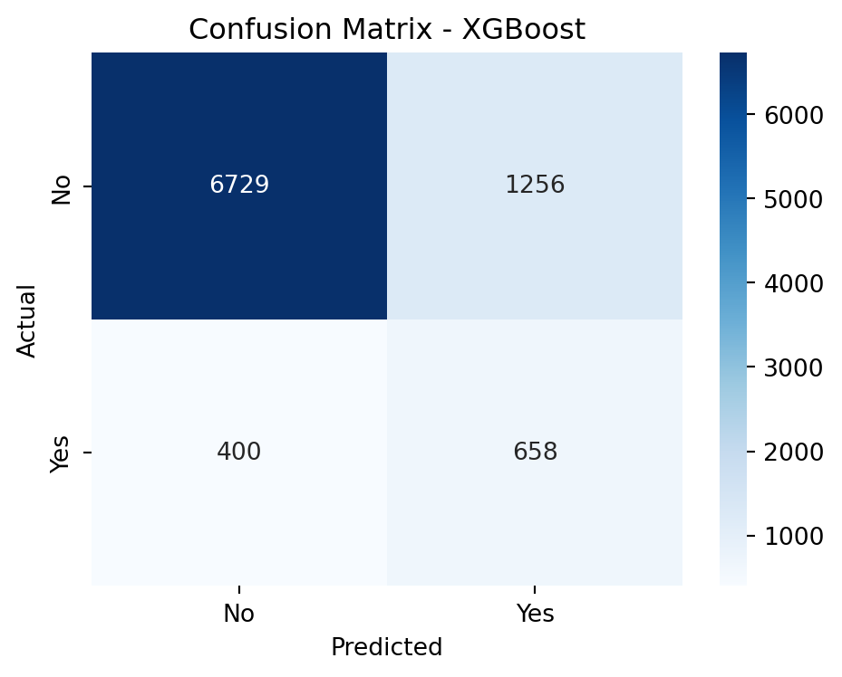

```python
# Winning model — detailed results with confusion matrix
xgb_results = evaluate_classification_model(
    model      = xgb_model,
    x_train    = x_train_down,
    x_test     = x_test,
    y_train    = y_train_down,
    y_test     = y_test,
    model_name = "XGBoost",
    show_confusion_matrix=True
)
```

> The confusion matrix shows the model correctly identifies the majority of actual subscribers while also classifying most non-subscribers accurately. Some false positives and false negatives remain, but the balance is well-aligned with the marketing objective: it is more valuable to flag a potential subscriber (even at the cost of a few false positives) than to miss one entirely.

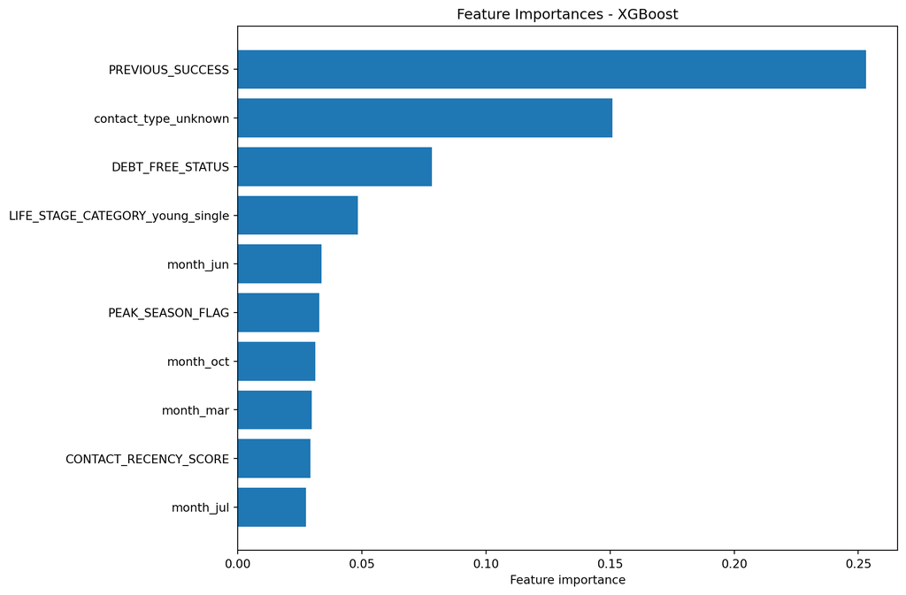

```python
plot_feature_importances(
    model         = xgb_model,
    train         = pd.DataFrame(x_train, columns=x_selected.columns),
    title         = "Feature Importances - XGBoost",
    export        = False,
    top_n         = 10
)
```

## **Conclusion**

In this project, we built and compared five classification models (Logistic Regression, Random Forest, XGBoost, Neural Network, and AdaBoost) to predict whether a bank client would subscribe to a term deposit. The dataset contained over 45,000 observations with a pronounced class imbalance, roughly 88% “no” versus 12% “yes,” making ROC-AUC the right primary evaluation metric.

Our pipeline started with column renaming for readability and IQR-based outlier imputation on two skewed numeric features, followed by the creation of 18 engineered features covering financial stability, campaign engagement, demographic segments, temporal patterns, and interaction effects. After one-hot encoding, manual feature selection down to 34 features, a stratified 80/20 train-test split, `StandardScaler` normalization fitted on training data only, and majority-class downsampling on the training set, all five models were trained on the balanced data with hyperparameters tuned via `tune_stable_auc` to maximize ROC-AUC while keeping the train-test gap at or below 0.05.

From a business standpoint, this model can help the bank run more targeted outreach by prioritizing clients with a higher likelihood of converting, which reduces unnecessary contacts and improves campaign ROI.

Looking ahead, further improvements could come from testing alternative resampling strategies like SMOTE, incorporating additional external data sources, or deploying the model with a decision threshold calibrated to the bank’s specific tolerance for false positives versus false negatives.

## **References**

Moro, S., Rita, P., & Cortez, P. (2014). Bank Marketing Dataset. UCI Machine Learning Repository. https://archive.ics.uci.edu/dataset/222/bank+marketing.

## **Appendix**

### **Hyper Parameter Tuning**

All hyperparameters used in Step 5 were selected through the `tune_stable_auc` function defined below. This wrapper runs either `RandomizedSearchCV` or `GridSearchCV`, ranks candidates by cross-validated ROC-AUC, filters for configurations where the train–test ROC-AUC gap ≤ 0.05, and refits the best stable configuration on the full training set. If no candidate meets the gap constraint, it falls back to the candidate with the smallest gap.

#### Graphical Tuning – XGBoost `max_depth`

The plot below sweeps `max_depth` values for XGBoost and shows train vs. test ROC-AUC. It confirms that moderate depths (4–6) provide the best trade-off between model capacity and generalization; deeper trees overfit.

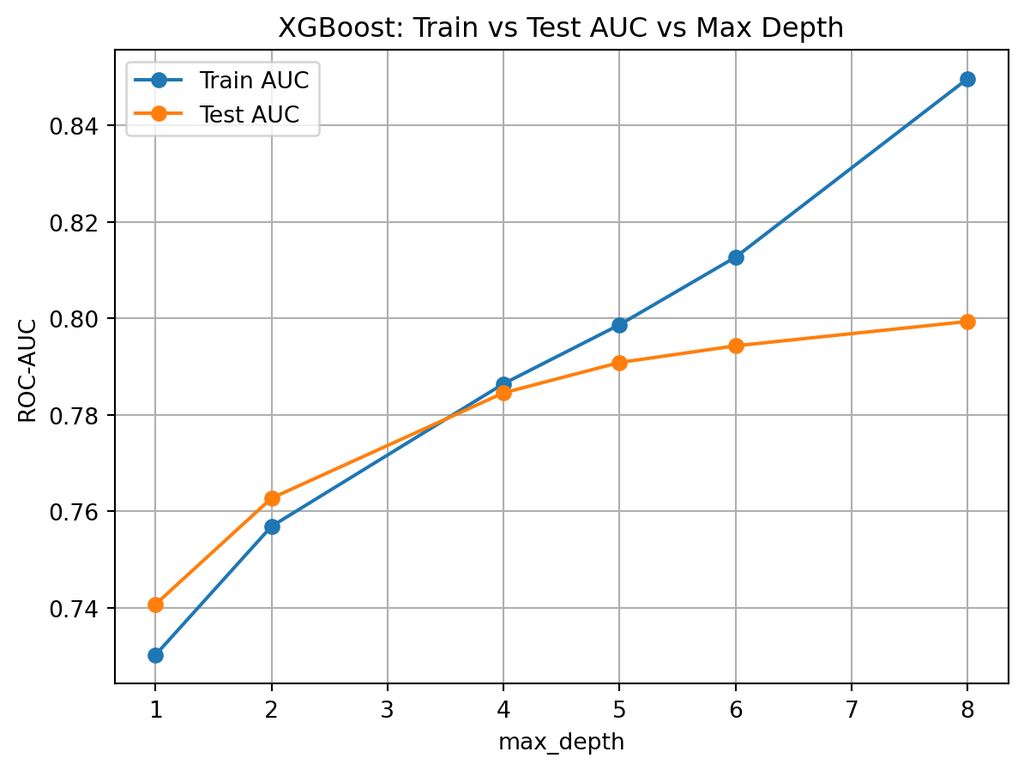

```python
# Max depth graphical optimization
depths = [1, 2, 4, 5, 6, 8]

train_auc, test_auc = [], []

for d in depths:
    model = xgb.XGBClassifier(
        max_depth=d,
        n_estimators=200,
        learning_rate=0.01,
        subsample=0.8,
        random_state=42,
        eval_metric="logloss",
        n_jobs=-1
    )

    model.fit(x_train_down, y_train_down)

    train_auc.append(
        roc_auc_score(y_train_down, model.predict_proba(x_train_down)[:,1])
    )

    test_auc.append(
        roc_auc_score(y_test, model.predict_proba(x_test)[:,1])
    )

# Plot
plt.figure()
plt.plot(depths, train_auc, marker='o', label="Train AUC")
plt.plot(depths, test_auc, marker='o', label="Test AUC")

plt.xlabel("max_depth")
plt.ylabel("ROC-AUC")
plt.title("XGBoost: Train vs Test AUC vs Max Depth")
plt.legend()
plt.grid(True)
plt.show()
```

#### `tune_stable_auc` Function and Per-Model Tuning Code

The cells below contain the `tune_stable_auc` function and the tuning calls for all five models. The code is commented out for performance reasons — full execution takes approximately 30 minutes. If running in Google Colab, the T4-GPU runtime is recommended.

```python
# # Function to tune + enforce ROC-AUC gap <= 0.05 !!! USE T4 GPU FOR SPEED !!!
# def tune_stable_auc(
#     estimator, params, X_train, y_train, X_test, y_test,
#     method="random", n_iter=30, cv=5, scoring="roc_auc",
#     gap_max=0.05, random_state=42, n_jobs=-1, verbose=0
# ):
#     SearchCV = RandomizedSearchCV if method.lower().startswith("r") else GridSearchCV

#     search_kwargs = {
#         "estimator": estimator,
#         "scoring": scoring,
#         "cv": cv,
#         "n_jobs": n_jobs,
#         "return_train_score": True,
#         "refit": False,
#         "verbose": verbose
#     }

#     if SearchCV is RandomizedSearchCV:
#         search_kwargs["param_distributions"] = params
#         search_kwargs["n_iter"] = n_iter
#         search_kwargs["random_state"] = random_state
#     else: # GridSearchCV
#         search_kwargs["param_grid"] = params

#     search = SearchCV(**search_kwargs)
#     search.fit(X_train, y_train)
#     r = pd.DataFrame(search.cv_results_)
#     r["gap"] = r["mean_train_score"] - r["mean_test_score"]

#     stable = r[r["gap"] <= gap_max]
#     pick = stable.loc[stable["mean_test_score"].idxmax()] if len(stable) else r.loc[r["gap"].abs().idxmin()]

#     best_params = pick["params"]
#     model = clone(estimator).set_params(**best_params)  # keeps your base estimator settings
#     model.fit(X_train, y_train)

#     p_tr = model.predict_proba(X_train)[:, 1]
#     p_te = model.predict_proba(X_test)[:, 1]
#     auc_tr = roc_auc_score(y_train, p_tr)
#     auc_te = roc_auc_score(y_test, p_te)

#     return {
#         "model": model,
#         "best_params": best_params,
#         "cv_auc": float(pick["mean_test_score"]),
#         "train_auc": float(auc_tr),
#         "test_auc": float(auc_te),
#         "gap": float(auc_tr - auc_te),
#         "stable_found": int(len(stable)),
#     }
```

```python
# # Logistic Regression (used downsampled train) - 5 seconds - 20 seconds Run Time
# lr = LogisticRegression(random_state=42, max_iter=2000)
# lr_params = {"C": [0.05, 0.1, 0.2], "solver": ["newton-cg", "lbfgs"]}

# lr_results = tune_stable_auc(
#     lr, lr_params,
#     x_train_down, y_train_down, x_test, y_test,
#     method="grid", cv=5, scoring="roc_auc", gap_max=0.05
# )
```

```python
# # Random Forest (used downsampled train) - 6 minutes - 10 minutes Run Time
# rf = RandomForestClassifier(random_state=42, n_jobs=-1)
# rf_params = {
#     "n_estimators": [300, 500],
#     "max_depth": [5, 10, None],
#     "min_samples_split": [2, 5, 10],
#     "min_samples_leaf": [1, 2, 4],
#     "max_features": ["sqrt", "log2"]
# }

# rf_results = tune_stable_auc(
#     rf, rf_params,
#     x_train_down, y_train_down, x_test, y_test,
#     method="random", n_iter=30, cv=5, scoring="roc_auc", gap_max=0.05, random_state=42
# )
```

```python
# # AdaBoost (you used full train) - 5 Minute - 10 Minute Run Time
# ada = AdaBoostClassifier(random_state=42)
# ada_params = {
#     "n_estimators": [200, 300, 400, 500],
#     "learning_rate": [0.05, 0.1, 0.5, 1.0],
#     "algorithm": ["SAMME", "SAMME.R"]
# }

# ada_results = tune_stable_auc(
#     ada, ada_params,
#     x_train, y_train, x_test, y_test,
#     method="random", n_iter=25, cv=5, scoring="roc_auc", gap_max=0.05, random_state=42
# )
```

```python
# # Neural Net ) - !! 8 Minute - 15 Minute Run Time !!
# nn_base = MLPClassifier(
#     random_state=42,
#     solver="adam",
#     activation="relu",
#     early_stopping=True
# )

# # centered around your best:
# # (64,), lr_init=0.005, alpha=0.000215, batch=128, val_frac=0.15, n_no_change=50, tol=1e-5, max_iter=2000
# nn_params = {
#     "hidden_layer_sizes": [(48,), (64,), (80,), (64, 32)],
#     "learning_rate": ["adaptive"],
#     "learning_rate_init": [0.003, 0.005, 0.007],
#     "alpha": [1e-4, 2.15e-4, 5e-4],
#     "batch_size": [64, 128],
#     "validation_fraction": [0.10, 0.15, 0.20],
#     "n_iter_no_change": [25, 50],
#     "tol": [1e-4, 1e-5],
#     "max_iter": [2000]
# }

# nn_results = tune_stable_auc(
#     nn_base, nn_params,
#     x_train, y_train, x_test, y_test,
#     method="random", n_iter=25, cv=5, scoring="roc_auc", gap_max=0.05, random_state=42
# )
```

```python
# # XGBoost (full train + scale_pos_weight on TRAIN only) - 2 Minute - 5 Minute Run Time
# xgb_base = xgb.XGBClassifier(
#     random_state=42,
#     eval_metric="logloss",
#     n_jobs=-1
# )

# xgb_params = {
#     "n_estimators": [150, 200, 250],
#     "max_depth": [4, 5, 6, 7],
#     "learning_rate": [0.005, 0.01, 0.02],
#     "subsample": [0.7, 0.8, 0.9]
# }

# xgb_results = tune_stable_auc(
#     xgb_base, xgb_params,
#     x_train_down, y_train_down, x_test, y_test,
#     method="random", n_iter=25, cv=5, scoring="roc_auc", gap_max=0.05, random_state=42
# )
```

```python
# # ---- Collect best models (minimal)
# all_results = {
#     "LogReg": lr_results,
#     "RF": rf_results,
#     "Ada": ada_results,
#     "XGB": xgb_results,
#     "NN": nn_results
# }
```

```python
# summary_df = pd.DataFrame.from_dict(
#     {
#         k: {
#             "CV_ROC_AUC": v["cv_auc"],
#             "Train_ROC_AUC": v["train_auc"],
#             "Test_ROC_AUC": v["test_auc"],
#             "Gap": v["gap"],
#             "Stable_Models": v["stable_found"]
#         }
#         for k, v in all_results.items()
#     },
#     orient="index"
# ).round(4)

# summary_df = summary_df.sort_values("Test_ROC_AUC", ascending=False)

# summary_df
```

```python
# # Print the best parameters for each model
# for model in all_results:
#     print(model)
#     print(all_results[model]['best_params'])
#     print()
```